# Red wine Analysis by Saurabh Sarkar

Determine the effect of different factors on the quality of Red Wine. We will take a Descriptive Statistical approach here, to describe the collected data. A more complex approach to build a predictor model is well suited for the next phase of analysis

The collected Red Wine dataset is a basic structure with 1599 indexed observations and 13 variables. Of the 13 variables, there is one which is just the index, leaving 11 features that represent the independent variables and the single target variable or dependent variable, which represents the *quality* score of the wines.

```
## 'data.frame':    1599 obs. of  13 variables:
##  $ X                   : int  1 2 3 4 5 6 7 8 9 10 ...
##  $ fixed.acidity       : num  7.4 7.8 7.8 11.2 7.4 7.4 7.9 7.3 7.8 7.5 ...
##  $ volatile.acidity    : num  0.7 0.88 0.76 0.28 0.7 0.66 0.6 0.65 0.58 0.5 ...
##  $ citric.acid         : num  0 0 0.04 0.56 0 0 0.06 0 0.02 0.36 ...
##  $ residual.sugar      : num  1.9 2.6 2.3 1.9 1.9 1.8 1.6 1.2 2 6.1 ...
##  $ chlorides           : num  0.076 0.098 0.092 0.075 0.076 0.075 0.069 0.065 0.073 0.071 ...
##  $ free.sulfur.dioxide : num  11 25 15 17 11 13 15 15 9 17 ...
##  $ total.sulfur.dioxide: num  34 67 54 60 34 40 59 21 18 102 ...
##  $ density             : num  0.998 0.997 0.997 0.998 0.998 ...
##  $ pH                  : num  3.51 3.2 3.26 3.16 3.51 3.51 3.3 3.39 3.36 3.35 ...
##  $ sulphates           : num  0.56 0.68 0.65 0.58 0.56 0.56 0.46 0.47 0.57 0.8 ...
##  $ alcohol             : num  9.4 9.8 9.8 9.8 9.4 9.4 9.4 10 9.5 10.5 ...
##  $ quality             : int  5 5 5 6 5 5 5 7 7 5 ...
```

```
##   X fixed.acidity volatile.acidity citric.acid residual.sugar chlorides
## 1 1           7.4             0.70        0.00            1.9     0.076
## 2 2           7.8             0.88        0.00            2.6     0.098
## 3 3           7.8             0.76        0.04            2.3     0.092
## 4 4          11.2             0.28        0.56            1.9     0.075
## 5 5           7.4             0.70        0.00            1.9     0.076
## 6 6           7.4             0.66        0.00            1.8     0.075
##   free.sulfur.dioxide total.sulfur.dioxide density   pH sulphates alcohol
## 1                  11                   34  0.9978 3.51      0.56     9.4
## 2                  25                   67  0.9968 3.20      0.68     9.8
## 3                  15                   54  0.9970 3.26      0.65     9.8
## 4                  17                   60  0.9980 3.16      0.58     9.8
## 5                  11                   34  0.9978 3.51      0.56     9.4
## 6                  13                   40  0.9978 3.51      0.56     9.4
##   quality
## 1       5
## 2       5
## 3       5
## 4       6
## 5       5
## 6       5
```

# Explore

We start by looking at the the distribution of the individual variables to determine if the data collected is valid to determine correlation to *quality*. The script below uses the R *summary()* function tot show the IQR and central measures of all the variables. This is a good gauge to determine general distribution and identify possibilities for outliers

```
##  [1] "fixed.acidity"        "volatile.acidity"     "citric.acid"
##  [4] "residual.sugar"       "chlorides"            "free.sulfur.dioxide"
##  [7] "total.sulfur.dioxide" "density"              "pH"
## [10] "sulphates"            "alcohol"              "quality"
```

```
##  fixed.acidity   volatile.acidity  citric.acid    residual.sugar
##  Min.   : 4.60   Min.   :0.1200   Min.   :0.000   Min.   : 0.900
##  1st Qu.: 7.10   1st Qu.:0.3900   1st Qu.:0.090   1st Qu.: 1.900
##  Median : 7.90   Median :0.5200   Median :0.260   Median : 2.200
##  Mean   : 8.32   Mean   :0.5278   Mean   :0.271   Mean   : 2.539
##  3rd Qu.: 9.20   3rd Qu.:0.6400   3rd Qu.:0.420   3rd Qu.: 2.600
##  Max.   :15.90   Max.   :1.5800   Max.   :1.000   Max.   :15.500
##    chlorides       free.sulfur.dioxide total.sulfur.dioxide    density
##  Min.   :0.01200   Min.   : 1.00       Min.   :  6.00       Min.   :0.9901
##  1st Qu.:0.07000   1st Qu.: 7.00       1st Qu.: 22.00       1st Qu.:0.9956
##  Median :0.07900   Median :14.00       Median : 38.00       Median :0.9968
##  Mean   :0.08747   Mean   :15.87       Mean   : 46.47       Mean   :0.9967
##  3rd Qu.:0.09000   3rd Qu.:21.00       3rd Qu.: 62.00       3rd Qu.:0.9978
##  Max.   :0.61100   Max.   :72.00       Max.   :289.00       Max.   :1.0037
##        pH          sulphates         alcohol         quality
##  Min.   :2.740   Min.   :0.3300   Min.   : 8.40   Min.   :3.000
##  1st Qu.:3.210   1st Qu.:0.5500   1st Qu.: 9.50   1st Qu.:5.000
##  Median :3.310   Median :0.6200   Median :10.20   Median :6.000
##  Mean   :3.311   Mean   :0.6581   Mean   :10.42   Mean   :5.636
##  3rd Qu.:3.400   3rd Qu.:0.7300   3rd Qu.:11.10   3rd Qu.:6.000
##  Max.   :4.010   Max.   :2.0000   Max.   :14.90   Max.   :8.000
```

**Results**: The *quality* variable is discrete and and as the target variable will be correlated against the 11 different factors. The quality data consists of 6 discrete values with 8 being the highest 3 being the lowest. You can see below that the the most common *quality* values are 5 and 6, where 681 observations have a quality rating of 5 and 638 observations have a quality rating of 6.

```
##
##   3   4   5   6   7   8
##  10  53 681 638 199  18
```

The summary showing the median/mean and IQR for the predictive variables indicates that these variables are continuous. Even before we plot histograms for these, we can make some assessments for the skews by looking at the median, mean, and Max/Min values:

- The following variables [*fixed.acidity, volatile.acidity, citric.acid, residual.sugar*] show median and mean close to each other indicating a normal distribution, however the relatively higher max value identifies possible outliers. Some of the other factors [*free.sulfur.dioxide, total.sulfur.dioxide, sulphates,alcohol*] indicate similar distributions, but will require further visual represenatations to confirm.
- The remaining factor [*density* and *pH*) do not indicate outliers and have close median and mean values, and probably exhibit a normal distribution

We will confirm these findings in the next section, by observing the distribution of each variable by plotting histograms.

# Univariate Plots Section

In this section we will show the visual distribution of the individual variables and identify if transformations are needed before we start observing correlations. In this section we will better qualify the categories in the depeneant variable *quality*, and then determine the validity of the independent variables to be used to look at correlation to *quality* by observing their distributions. A normal distribution will be a strong candidate to observe further, along with distributions that show a normal behavior once transformed on log scale.

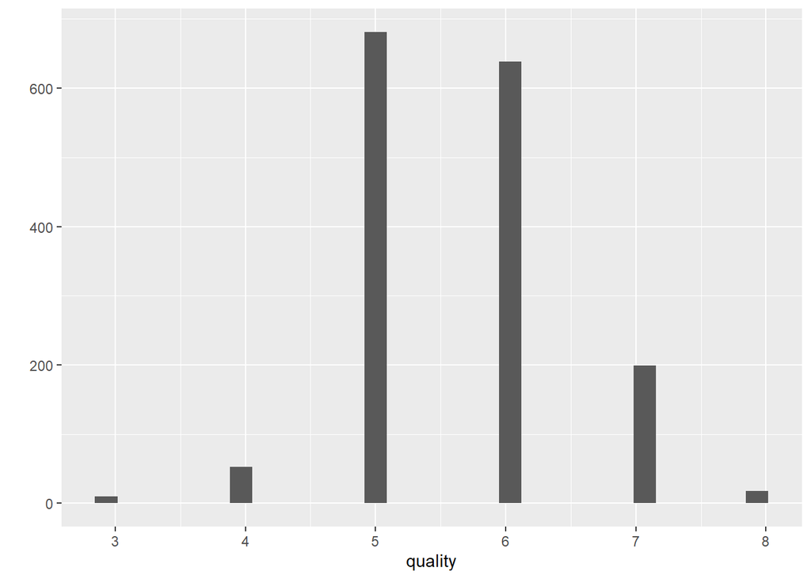

**Adjust Dependent variable** The variable *quality* is discrete with most of the data have quality level in the 5 or 6 quality level with a fewer examples for the higher or lower quality scores. To constitute a better frequency for the different categories, it will be beneficial to change the bracket size. It might be beneficial to split this into two brakcets if we were building a logistic regression model. But for descriptive purposes, the *quality* scores will be split into 3 brackets allowing us to better utilize the quality number as a predictor variable for the various wine quality variables. Utilizing basic ifelse statements, the *quality* variable is re-categorized into the 3 segments of *High*, *Average*, and *Low*. The resulting distribution can be seen below.

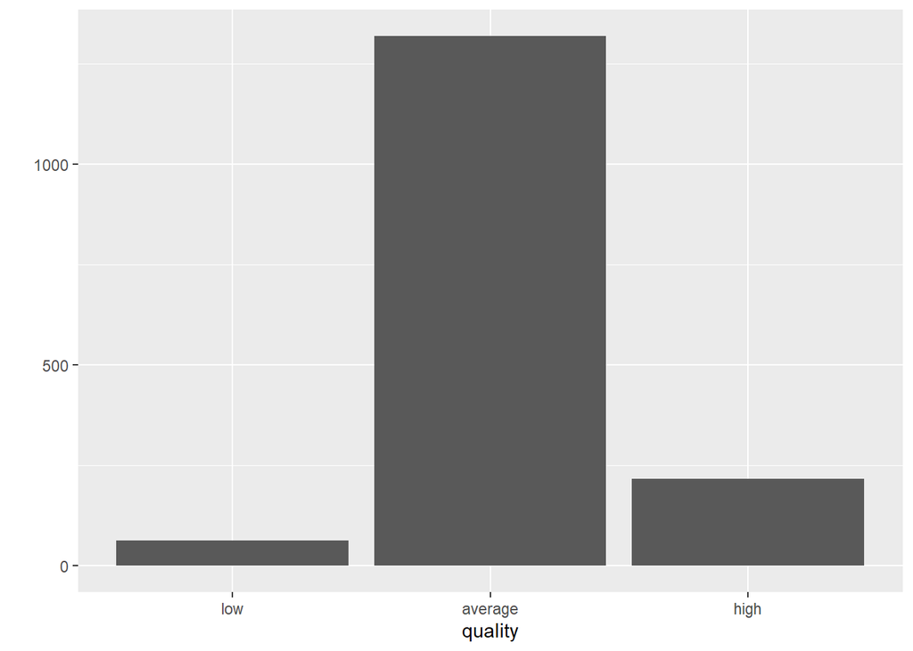

**Identify Normally distributed variables** With the dependent variable *quality* re-categorized, we can start the Univariate analysis of the independent variables. We start with *pH* and *density* as they previously indicated a Normal Distribution, and these are confirmed by the histograms below.

Plot Note: The same distribution with a smaller bin width is also provided next to the original plot to highlight a deeper look at the distribution and in turn confirm that the normal distribution is rarely a perfectly bell shaped curve

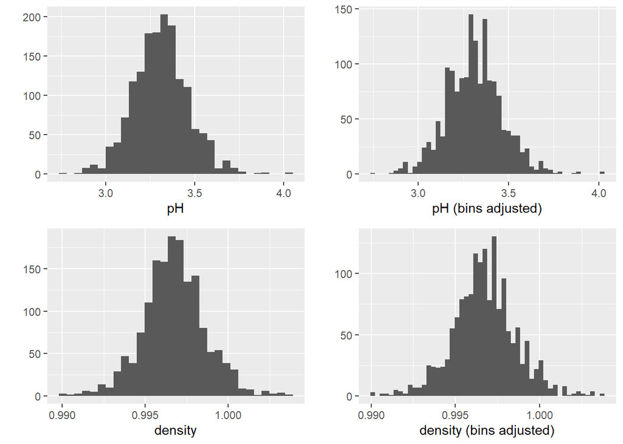

For the remaining variables, we had previously identified possible skews on the normal distribution. We will plot this visually and confirm that the extent of the skews and also confirm if transformations result in a normal distribution.

Plot Note: R allows for an iterative approach to plotting. The plots below were plotted by just identifying the x axis, and were then further refined, by adjusting factors like *binwidth* and *breaks*, to present the final visual distribution

Among the remaining variable to be observed, it can be seen that *fixed.acidity* is very close to a normal distribution. However like the variables [*‘residual.sugar’, ‘sulphates’, ‘total.sulfur.dioxide’, ‘chlorides’*], the distribution has a long tail and would benefit with a transformation.

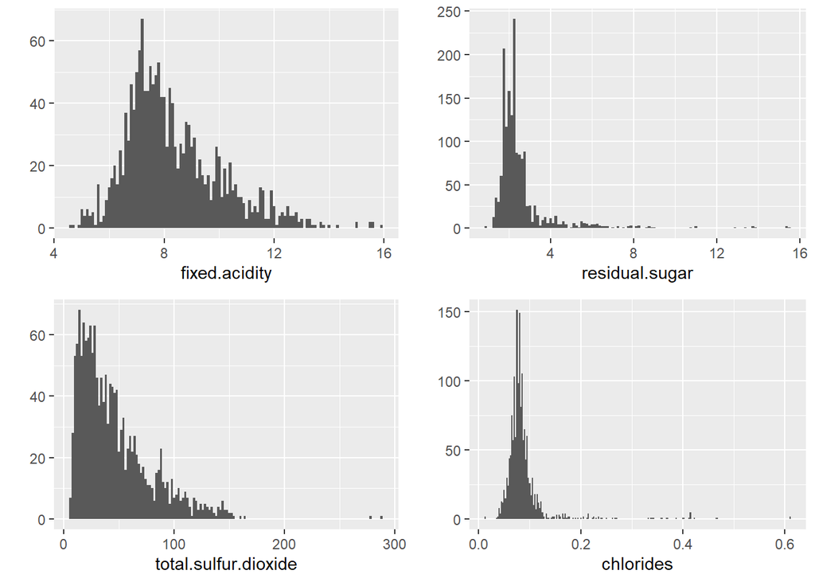

The variable *free.sulfur.dioxide* seems discrete after bins are shortened. This can probably also be constituted to rounding. It is interesting to see that the distribution does seem to exhibit a long trailing tail, so a transformation should be attempted

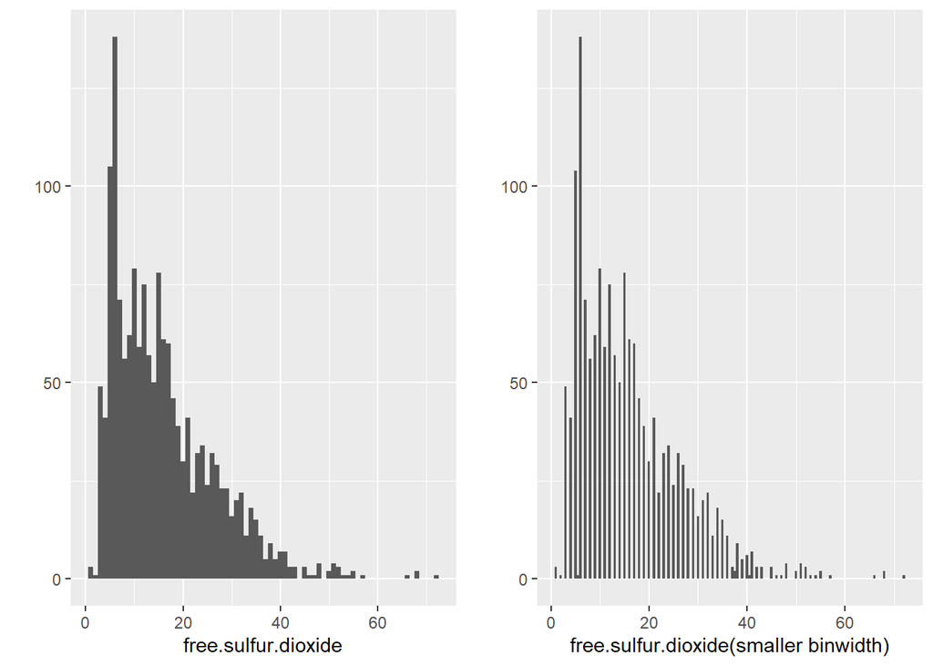

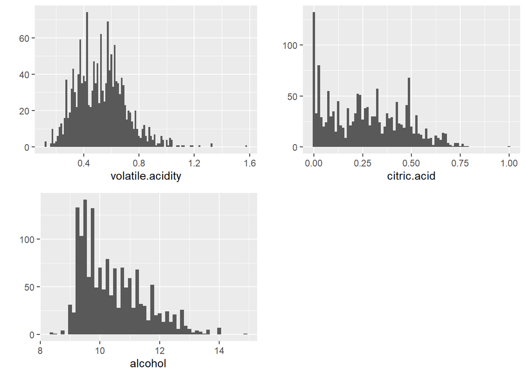

**Transformations for Normal distributions** Here, we will continue transforming the variables in an attempt to get a normal bell shaped distribution. For the variables [*fixed.acidity, residual.sugar, sulphates, total.sulfur.dioxied, ‘chlorides’*] we transformed the distributions using log10 and observed a more normal distribution

Readme Note: Previous plots were done using *qplot*. Plots moving forward will be done using *ggplot* allowing for the iterative approach to plotting while allowing for more control and refinement. For example in the plots below one variable [*p1*] is assigned the basic plot, and then the variation is created by *l1 = p1 + coord_trans(x = ‘log10’)*

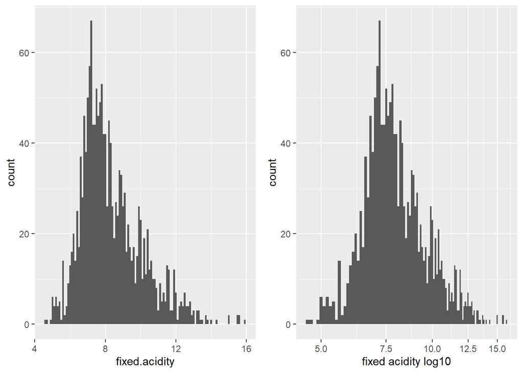

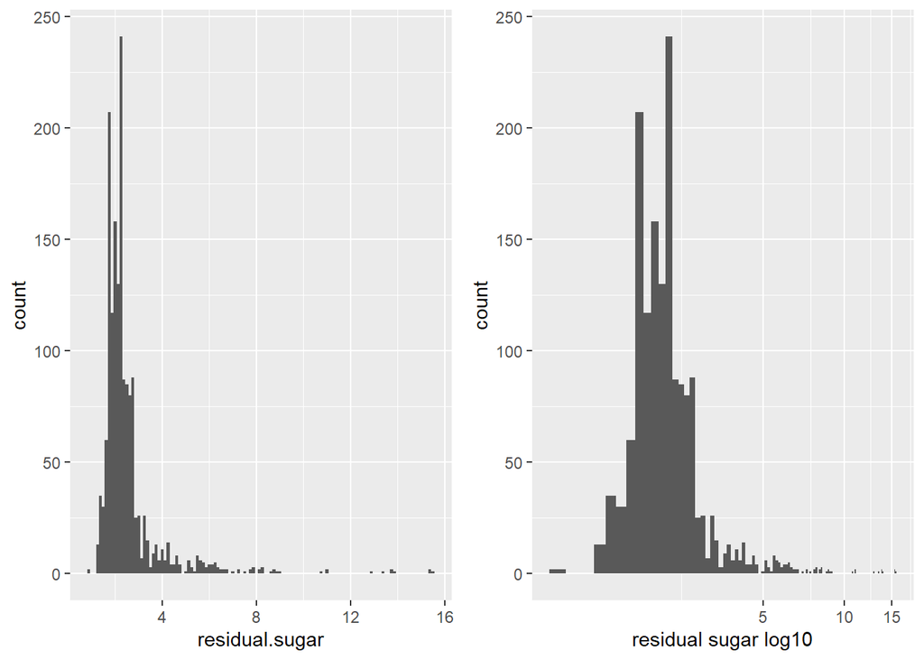

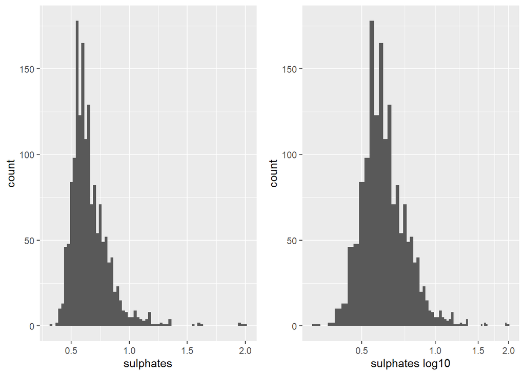

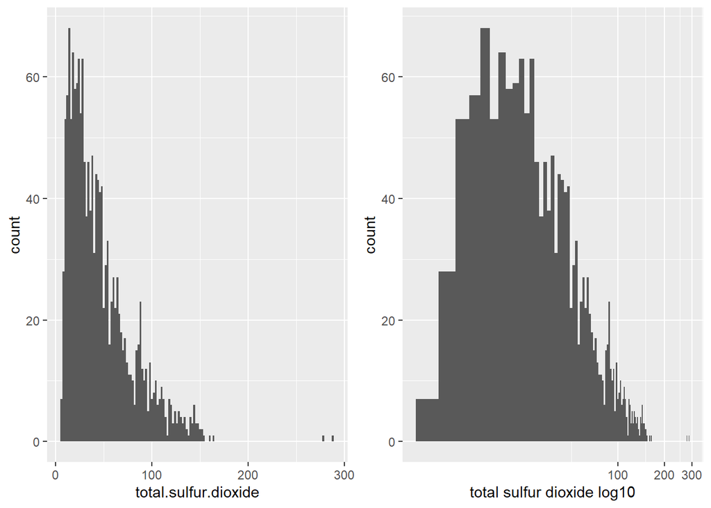

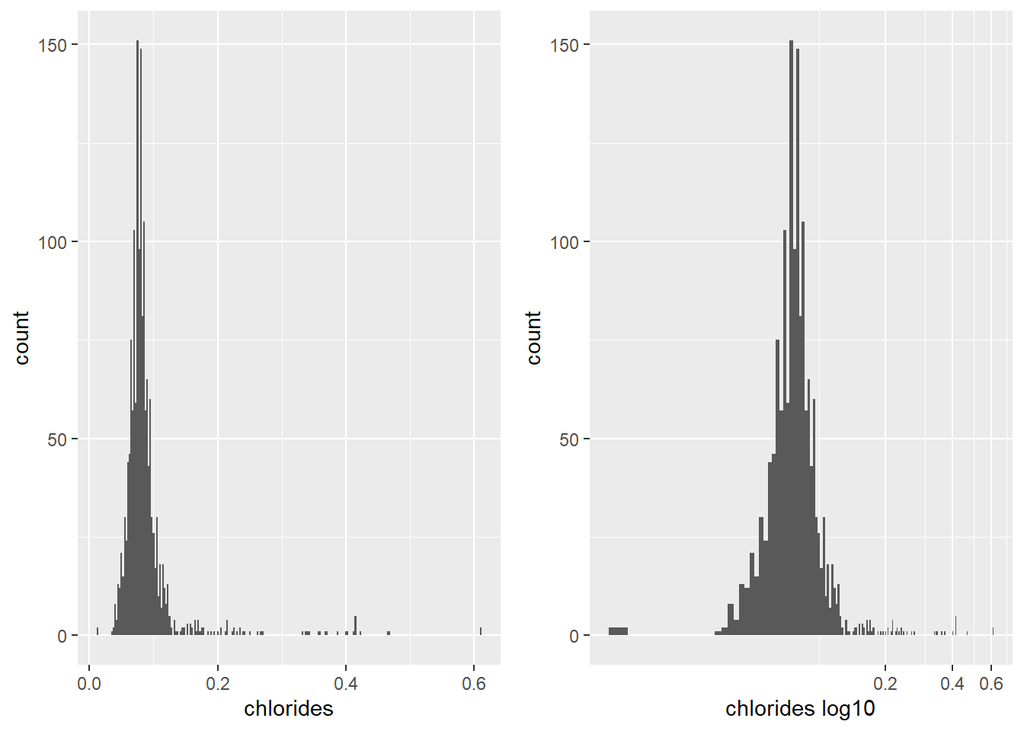

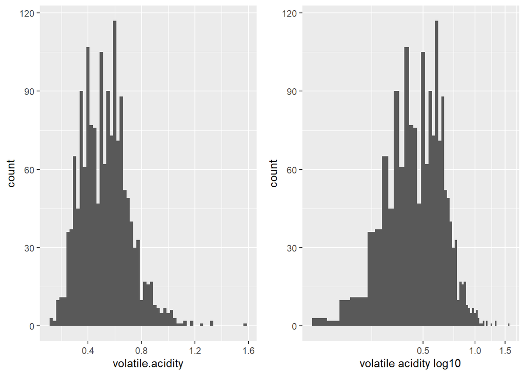

**Unable to Normalize** The plots below show the unsuccessful transformation of the variables *free sulfur dioxide*, *alcohol* and *citric acid* due the inability to normalize after applying transformations. It is difficult to form a conclusion on these and will require further investigation in bi-variate analysis. In later analysis the data can be subset to remove any null values.

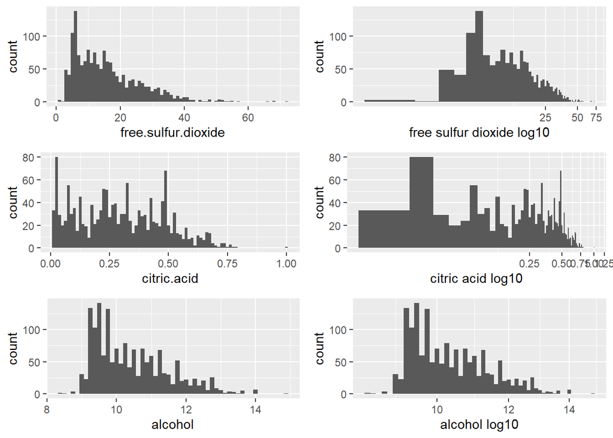

# Bivariate Plots Section

In this section we will observe the correlation of quality to the different variables. We had previously reduced the qine quality score to three values. We will compare this discrete quality values with the other continuous wine variables and identify trends using Box Plots

In the plots below forr *fixed acidity, volatile acidity, citric acid, sulphates, alcohol* we can see a general trend indicating a change in quality score influenced by a change in value of these variables. Within these variables, *alcohol* content seems to be the only exception where ‘bad’ and ‘good’ quality wines are not impacted by alcohol content. But it is worth including as a dependant variable as the ‘best’ quality wines seem to be determined by the higher alcohol content.

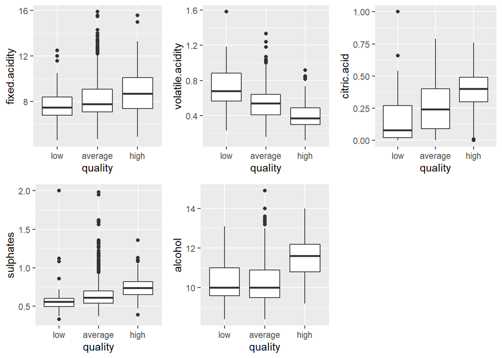

Whereas the plots for *residual sugar, chlorides, free sulfur dioxide, total sulfur dioxide, density, pH* do not indicate a correlation to the quality score of the wine. You can see from the plots below that for the different values within each variabe, the box plots indicating the distribution for the quality scores are generally identical ,or the differences of distribution is insignificant

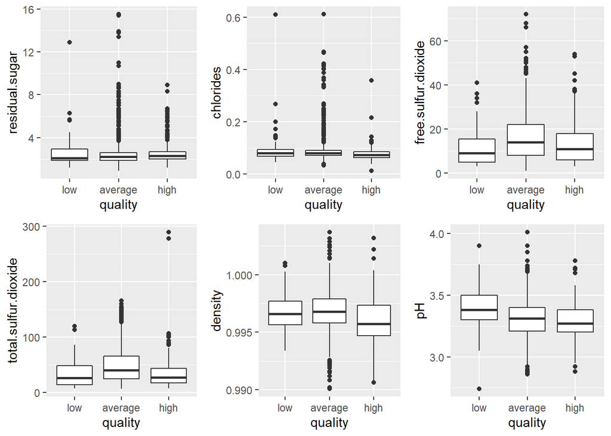

While building a model to identify correlation it is important to identify bias by verifying that the variables are in fact independent. Below we will check verify correlation using scatter plots.

It is good to see that while the variables *fixed acidity* and *volatile acidity* were indicated to show an effect on *quality* score, we can confirm that in fact they have have a WEAK negative correlation within themselves

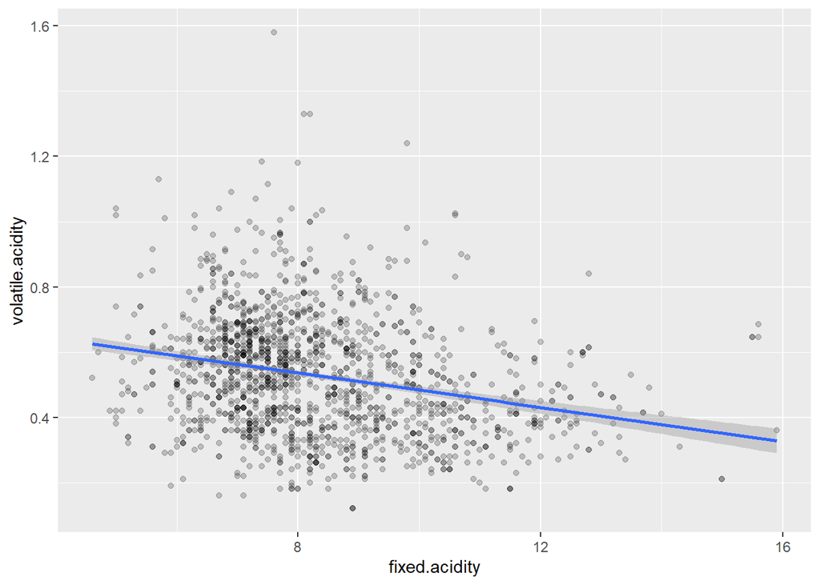

```
##
##  Pearson's product-moment correlation
##
## data:  fixed.acidity and volatile.acidity
## t = -10.589, df = 1597, p-value < 2.2e-16
## alternative hypothesis: true correlation is not equal to 0
## 95 percent confidence interval:
##  -0.3013681 -0.2097433
## sample estimates:
##        cor
## -0.2561309
```

The variables, *fixed acidity* and *citric acid*, on the other is just below the STRONG positive correlation

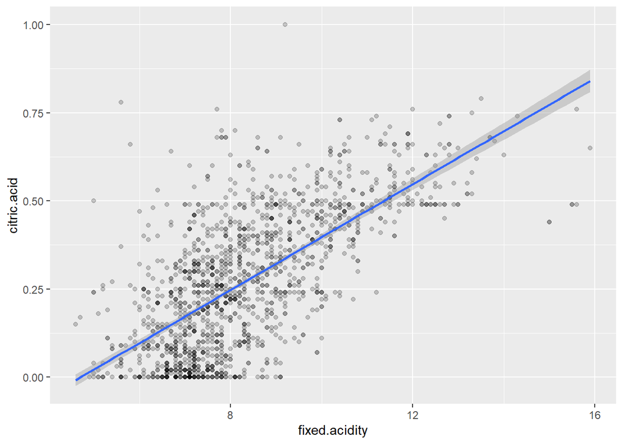

```
##
##  Pearson's product-moment correlation
##
## data:  fixed.acidity and citric.acid
## t = 36.234, df = 1597, p-value < 2.2e-16
## alternative hypothesis: true correlation is not equal to 0
## 95 percent confidence interval:
##  0.6438839 0.6977493
## sample estimates:
##       cor
## 0.6717034
```

While the Varaibles, *volatile acidity* and *citric acid* are not strongly correlated either

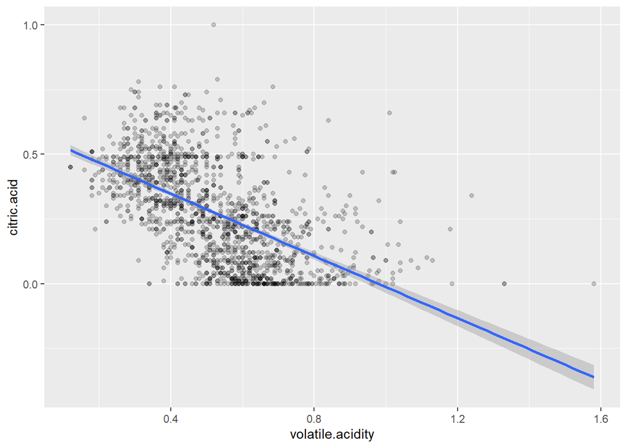

```
##
##  Pearson's product-moment correlation
##
## data:  volatile.acidity and citric.acid
## t = -26.489, df = 1597, p-value < 2.2e-16
## alternative hypothesis: true correlation is not equal to 0
## 95 percent confidence interval:
##  -0.5856550 -0.5174902
## sample estimates:
##        cor
## -0.5524957
```

**Observing pH correation with acid levels**: It is interesting to see the ‘pH’ doesn’t have much of an effect while the different acidity levels does. Below, we will continue to spot correlations within the variables that influence *quailty*.

- Both *citric.acid* and *fixed.acidity* have the expected negative correlation with pH, however the variable *volatile.acidity* has a weak correlation of ~0.23. This confirms that *Volatile acidity* constitutes strongly to the quality of the wine, while not having a significant effect on the pH of the wine

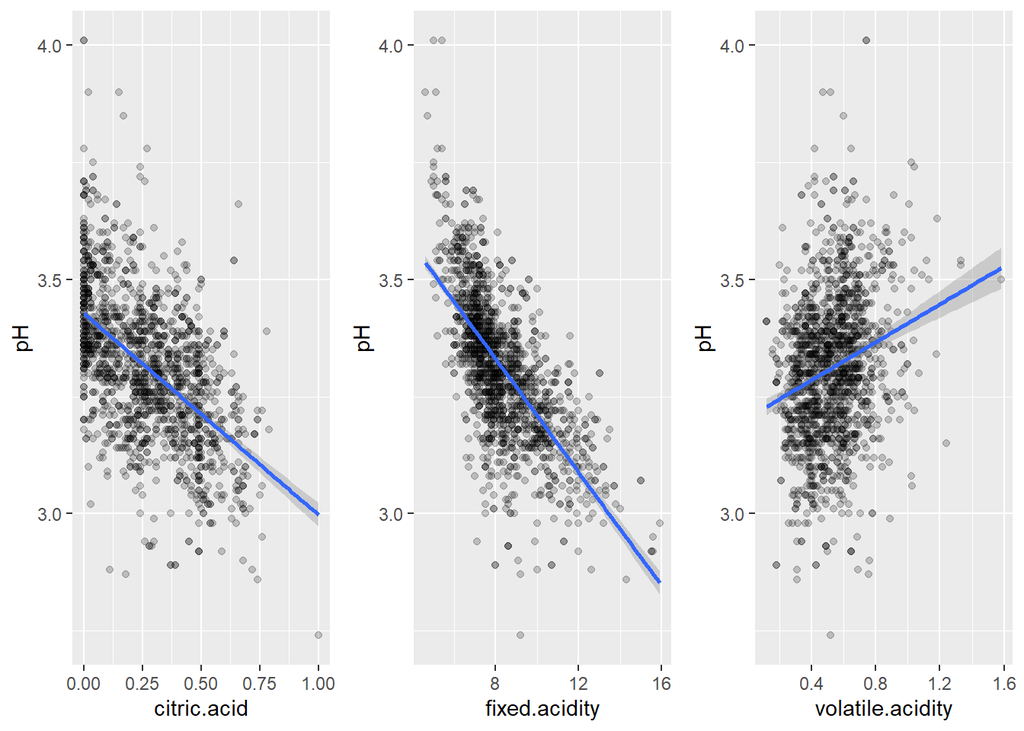

```
##
##  Pearson's product-moment correlation
##
## data:  volatile.acidity and pH
## t = 9.659, df = 1597, p-value < 2.2e-16
## alternative hypothesis: true correlation is not equal to 0
## 95 percent confidence interval:
##  0.1880823 0.2807254
## sample estimates:
##       cor
## 0.2349373
```

Below, we continue looking at the other correlations that do not affect *quality*. These are captured if it becomes necessary as the model is further enhanced when evaluating ‘White Wine’ data. But for our purposes looking at just ‘Red Wine’ data we have seen before that they do not affect *quality* scores. It is also worth noting that the univariate analysis had identified prime candidates in *pH* and *density* as independent variables due to the normal distributions but then rejected as valide candidates once the correlation to the dependant variable *quality* showed an insignificant effect.

*free sulfur dioxide* and *total sulfur dioxide* has a strong positive correlation

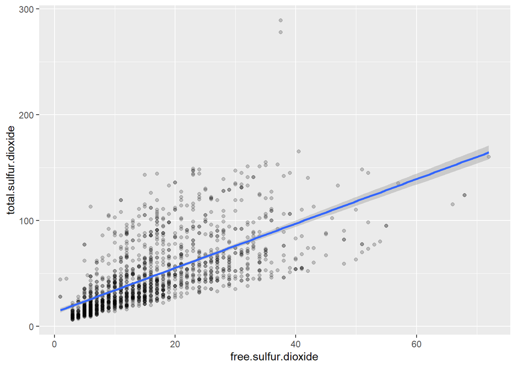

```
##
##  Pearson's product-moment correlation
##
## data:  free.sulfur.dioxide and total.sulfur.dioxide
## t = 35.84, df = 1597, p-value < 2.2e-16
## alternative hypothesis: true correlation is not equal to 0
## 95 percent confidence interval:
##  0.6395786 0.6939740
## sample estimates:
##       cor
## 0.6676665
```

The variables *total sulfur dioxide* and *sulphates*, unlike above, has no correlation

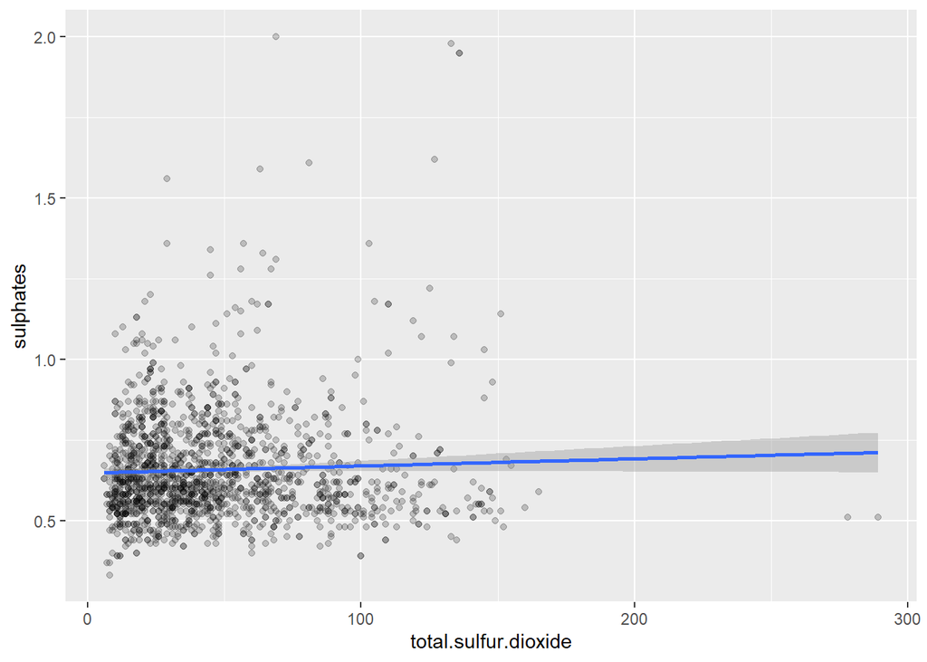

```
##
##  Pearson's product-moment correlation
##
## data:  total.sulfur.dioxide and sulphates
## t = 1.7178, df = 1597, p-value = 0.08602
## alternative hypothesis: true correlation is not equal to 0
## 95 percent confidence interval:
##  -0.006087119  0.091774762
## sample estimates:
##        cor
## 0.04294684
```

Even though *sulphates* does not have any correlation to *total sulfur dioxide*, it does seem to have a medium strength correlation to acid levels, primarily *citric acid* as seen below

[figure not shown]

```
##
##  Pearson's product-moment correlation
##
## data:  citric.acid and sulphates
## t = 13.159, df = 1597, p-value < 2.2e-16
## alternative hypothesis: true correlation is not equal to 0
## 95 percent confidence interval:
##  0.2678558 0.3563278
## sample estimates:
##     cor
## 0.31277
```

*density* and *alcohol* have a medium strength negative correlation

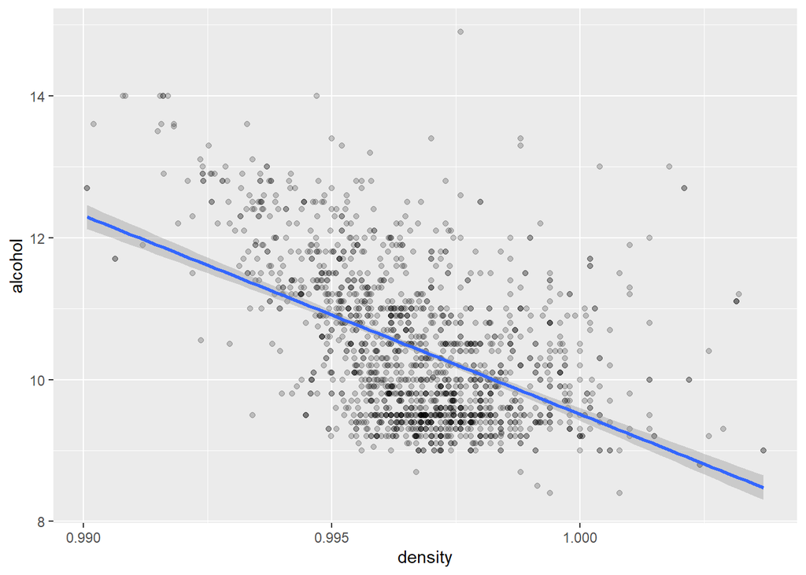

```
##
##  Pearson's product-moment correlation
##
## data:  density and alcohol
## t = -22.838, df = 1597, p-value < 2.2e-16
## alternative hypothesis: true correlation is not equal to 0
## 95 percent confidence interval:
##  -0.5322547 -0.4583061
## sample estimates:
##        cor
## -0.4961798
```

### Bivariate Analysis - Summary

- **Features of Interest**: The plots for *fixed acidity, volatile acidity, citric acid, sulphates, alcohol* indicate an influence on the quality. *Alcohol* content is an exception among these as it has there is not affect on the ‘low’ and ‘medium’ scored qualities. The distinction is seen with the ‘best’ quality wines where a a higher alcohol content indcates an improvement in *quality*.
- **Non-main features of interest**: *Citric acid* have negative correlation with *volatile acidity* while *citric acid* has a positive correlation with *fixed acidity*. *alcohol* and *density* has a medium strength negative correlation
- **Strongest Relationship**: *volatile.acidity* in its affect on *quality* as seen in the box plot shows the clearest separation of distribution for each *quality* scores. It is also worth noting that *fixed acidity* and *citric acid* are independant variables that have a mid-strong level correlation

# Multivariate Plots Section

In this section we are going to further enhance the analysis earlier and take steps to identify correlations while faceting by the *quality* factors.

Looking at the strong correlation between *fixed.acidity* and *citric.acid*. Once separated by *quality* we can see an indication for higher quality when levels for *fixed.acidity* and *citric.acid* are higher

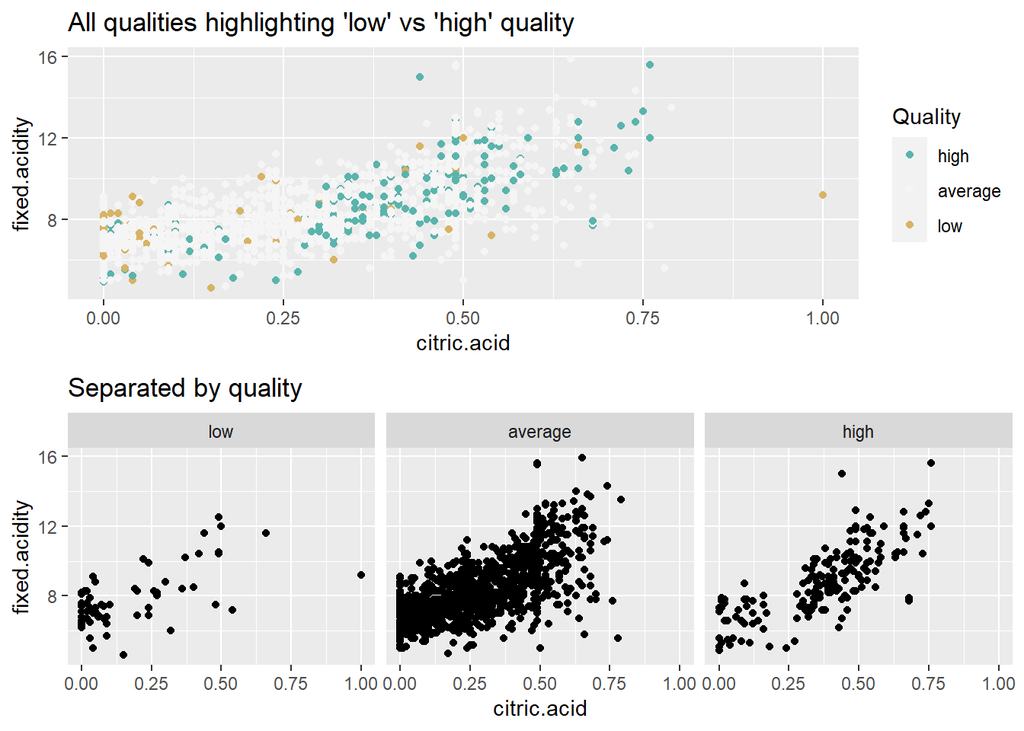

Now looking at the MEDIUM strength correlation of *volatile.acidity* and *citric.acid*. A concentration of low volatile acidity also seems evident for ‘high’ quality wine

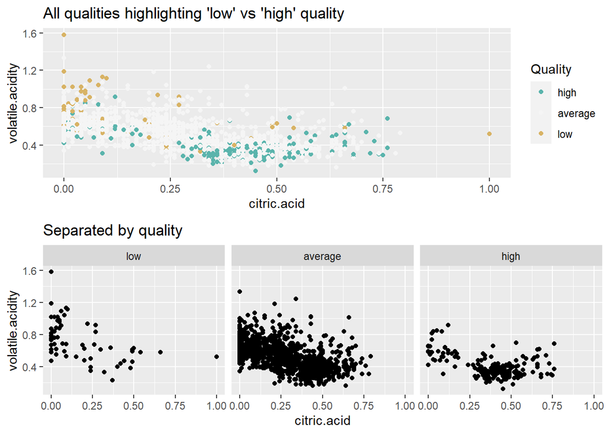

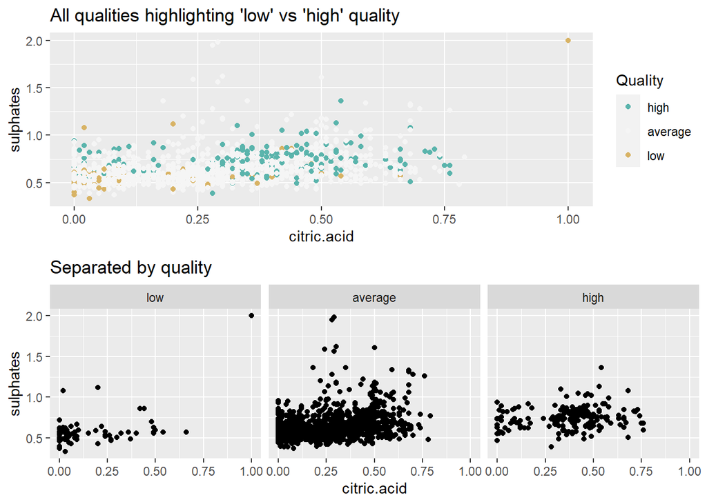

The confusion for the influence of *alcohol* is evident from these plots with a high variance in the plots for both ‘average’ and ‘high’ quality wine, but the concentration for the plot pattern in ‘high’ quality indicates an influence in quality for higher values of *alcohol*

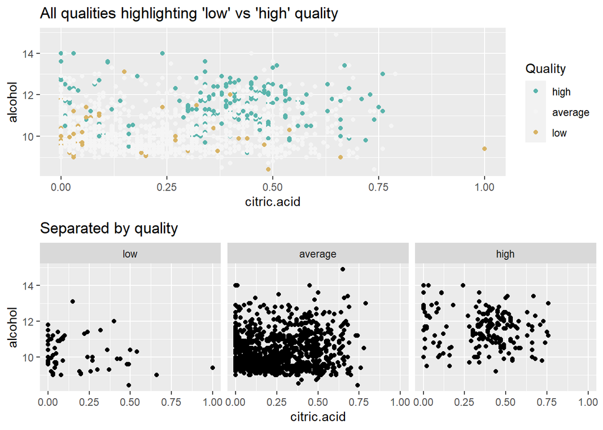

It would interesting to further observe the influence of alcohol. This time we plot *alcohol* against *density*. We confirm the similar concentration of points within the 11-13 alcohol axis in the ‘high’ quality section

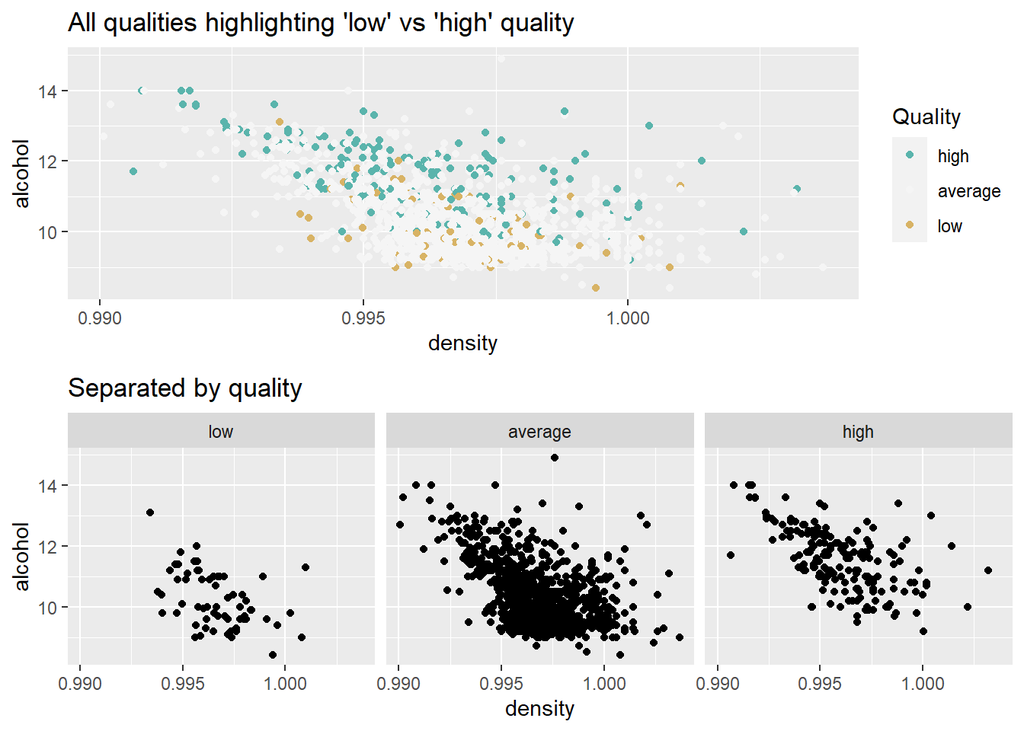

Some useful insight from the plots showing that the different levels of variables [*citric.acid, fixed.acidity, volatile.acidity, suplphates, alcohol*] does in fact influence *quality*. Better insight can be achieved by creating another variable which includes a discrete view by splitting up the continuous variables into buckets.

Using the top 99.5% percentile for the variables [*citiric.acid, fixed.acidity, volatile.acidity, sulphates, alcohol*] and split it up into 3 equal buckets.

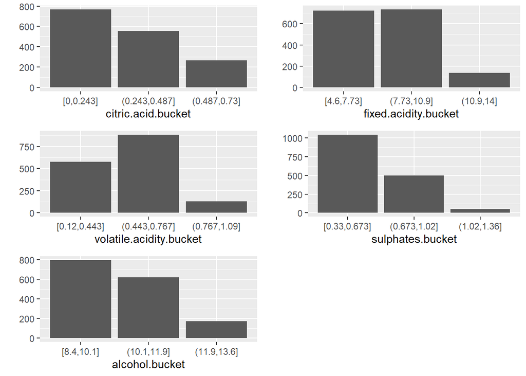

Using bucket for *fixed.acidity*, plotting *citric.acid* against *sulphates*, we can identify the different levels of *fixed.acidity* and *Citric.acid* that improve quality

**Using *vixed.acidity* bucket**: The 0.25 *citric acid* and ‘4.6-7.73’ (in green) *fixed acidity* level is common for ‘average’ level wine and almost non existent for ‘high’ quality, indicates a ‘sweet spot’ to avoid for that extra level of quality

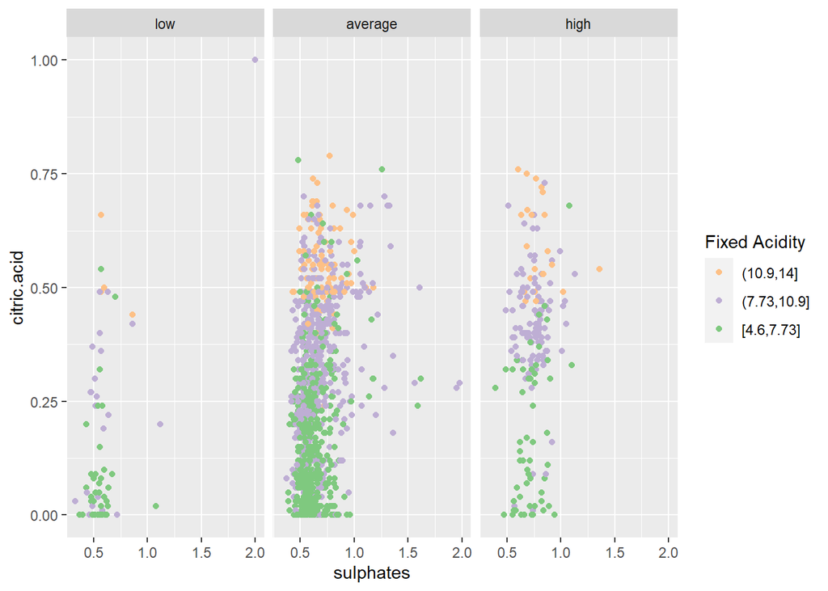

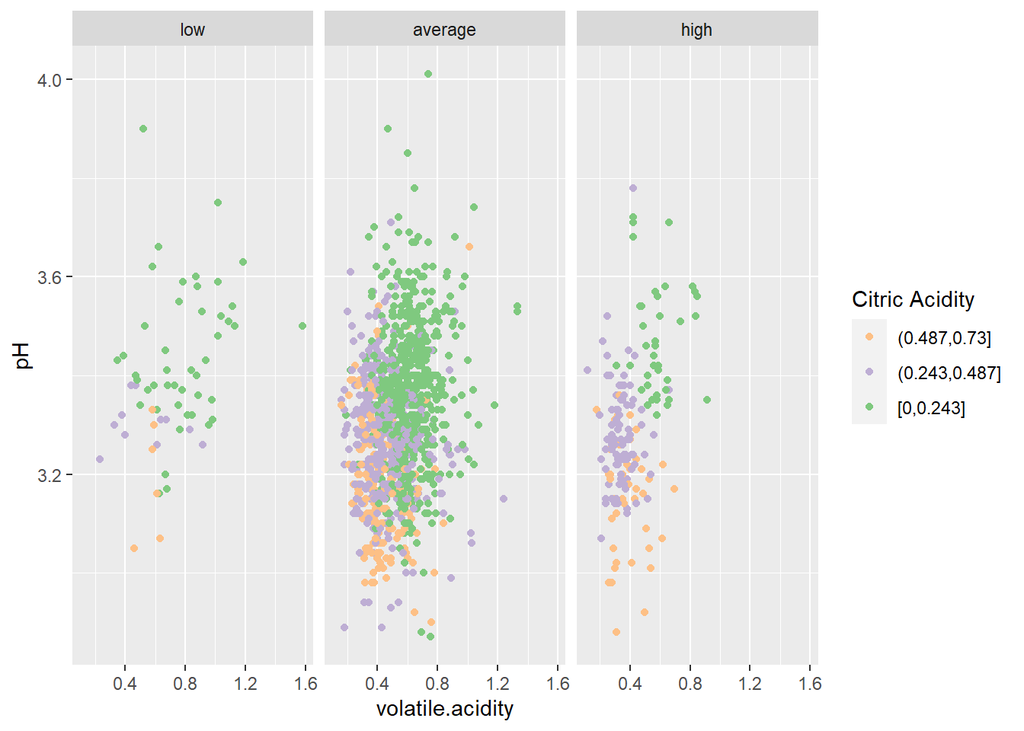